# Part I - Prosper Loan Data

## Multivariate Exploration

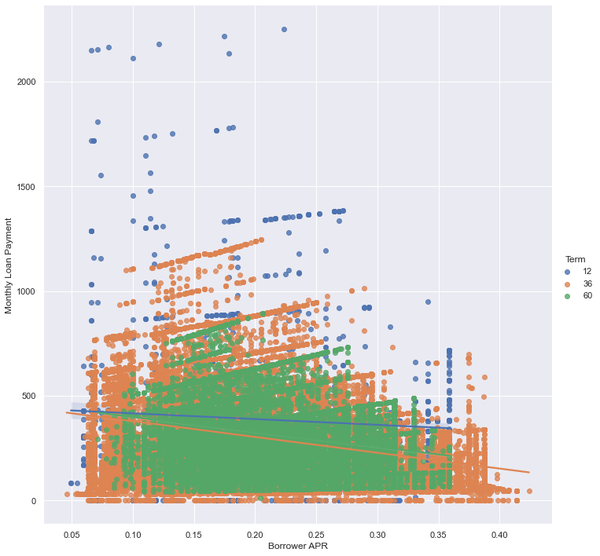

```python
# Plotting Borrower APR VS Monthly Loan Payment according to the term
g = sb.lmplot(
    data=df_prosper_loan,
    x="BorrowerAPR", y="MonthlyLoanPayment", hue="Term",
    height=10
)

g.set_axis_labels("Borrower APR", "Monthly Loan Payment");
```

It was shown that increase in borrower APR implies descrease in monthly loan payment especialy in those who took loan for 36 months.

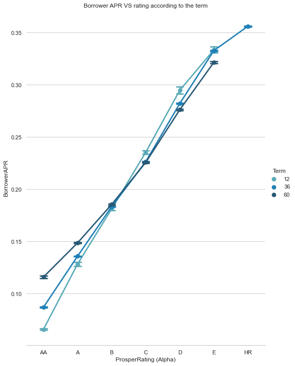

```python
# Plotting Borrower APR VS rating according to the term
sb.set_theme(style="whitegrid")

g = sb.catplot(x="ProsperRating (Alpha)", y="BorrowerAPR", hue="Term",
                capsize=.2, palette="YlGnBu_d", height=10, aspect=.75,
                kind="point", data=df_prosper_loan)
g.despine(left=True)
plt.title('Borrower APR VS rating according to the term');
```

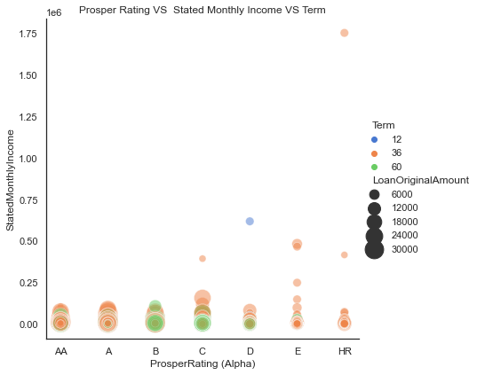

```python
# Plotting Prosper Rating VS  Stated Monthly Income with other semantics
sb.set_theme(style="white")

sb.relplot(x="ProsperRating (Alpha)", y="StatedMonthlyIncome", hue="Term", size="LoanOriginalAmount",
            sizes=(50, 500), alpha=.5, palette="muted",
            height=6, data=df_prosper_loan)
plt.title('Prosper Rating VS  Stated Monthly Income VS Term');
```

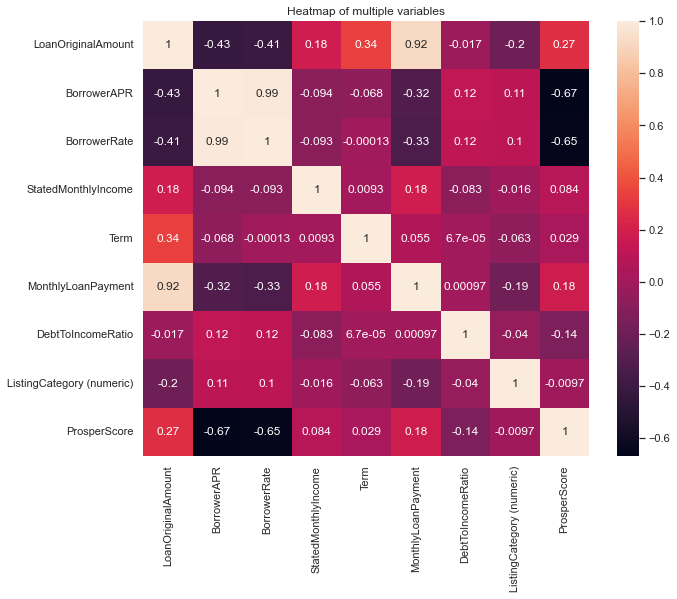

```python
# Plotting heatmap of multiple variables
plt.figure(figsize=(10,8))
corr_matrix = df_prosper_loan.corr()
sb.heatmap(corr_matrix,annot=True)
plt.title('Heatmap of multiple variables');
```

As Borrower APR and Borrower Rate were some how similar, they were highly correlated (99%). Also, monthly loan payment were highly correlated with loan original amount.